# Microbiome data science workflow

Standard components of a taxonomic profiling study

Monday, September 28, 2026

## The data science workflow

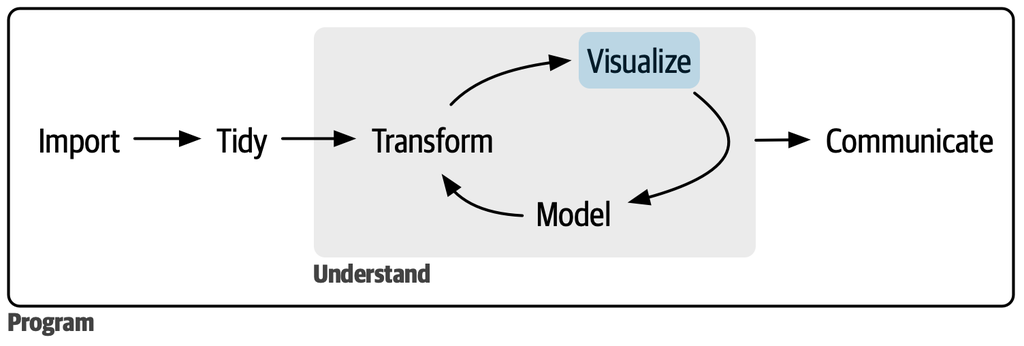

[R for Data Science](https://r4ds.hadley.nz) (Wickham, Çetinkaya-Rundel, and Grolemund 2023), CC BY-NC-ND 3.0

## A typical workflow

Import Preprocess Alpha Beta Taxa Report

- Key elements of a taxonomic profiling study
- Mixed and matched in real case studies
- Examples for each step in [OMA](https://microbiome.github.io/OMA/)

## Your task

Build a clear, compact and reproducible report on your data.

📓

Reproducible

Quarto / R Markdown report that renders from raw data

🎯

Selective

Choose summaries and analyses that answer your question

📚

Build on OMA

Reuse material and examples from the [OMA book](https://microbiome.github.io/OMA/)

## Setup

```r
library(mia)
library(miaViz)
library(scater)
library(patchwork)
set.seed(1)  # reproducible permutation tests

# Example data set: skin microbiome with sample metadata
data("peerj13075", package = "mia")
tse <- peerj13075

# Relative abundances and CLR for downstream steps
tse <- transformAssay(tse, method = "relabundance")
tse <- transformAssay(tse, method = "clr", pseudocount = TRUE)

# Genus-level summary
tse_genus <- agglomerateByRank(tse, rank = "genus")
```

# Alpha diversity

## Alpha diversity: within-sample

**Tasks**

1. Estimate alpha diversity per sample
2. Draw a histogram
3. Compare two or more indices, visually and/or statistically

```r
tse <- addAlpha(
    tse, index = c("shannon", "observed"))

p1 <- plotHistogram(
    tse, col.var = "shannon", bins = 15)
p2 <- plotColData(
    tse, x = "observed", y = "shannon")
p1 + p2
```

**Tip**

Do richness and evenness agree? Here Spearman $\rho$ = 0.43.

## Alpha diversity: within-sample

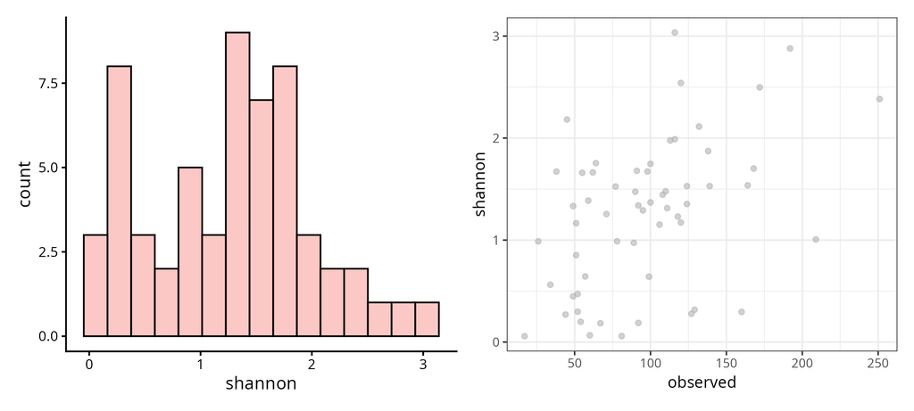

# Beta diversity

## Beta diversity: PCoA

Visualize community variation with **PCoA**, and check how the data transformation affects it:

Bray–Curtis

on compositional (relative abundance) data

Euclidean

on CLR-transformed data (Aitchison distance)

```r
tse <- runMDS(tse, FUN = getDissimilarity, method = "bray",
              assay.type = "relabundance", name = "PCoA_BC")
tse <- runMDS(tse, FUN = getDissimilarity, method = "euclidean",
              assay.type = "clr", name = "PCoA_CLR")

plotReducedDim(tse, "PCoA_BC",  colour_by = "Geographical_location") +
plotReducedDim(tse, "PCoA_CLR", colour_by = "Geographical_location") +
    plot_layout(guides = "collect")
```

## Beta diversity: PCoA

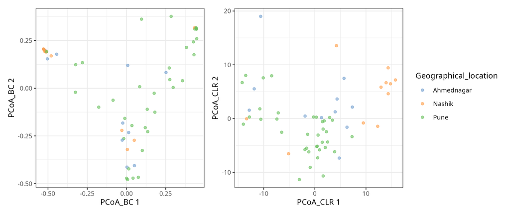

## Community-level comparisons

Does community composition differ between groups?

- **PERMANOVA** tests group differences in composition
- Add **covariates** (e.g. age, sex) and see how the results change
- Check homogeneity of dispersion

```r
res <- getPERMANOVA(
    tse,
    assay.type = "relabundance",
    method = "bray",
    formula = x ~ Geographical_location + Gender + Age,
    test.homogeneity = TRUE)

res$permanova |>
    knitr::kable(digits = 3)
```

## Community-level comparisons

|  | Df | SumOfSqs | R2 | F | Pr(>F) |
| --- | --- | --- | --- | --- | --- |
| Geographical_location | 2 | 1.956 | 0.093 | 2.887 | 0.001 |
| Gender | 1 | 0.238 | 0.011 | 0.702 | 0.698 |
| Age | 2 | 0.872 | 0.041 | 1.287 | 0.199 |
| Residual | 52 | 17.616 | 0.836 | NA | NA |
| Total | 57 | 21.079 | 1.000 | NA | NA |

# Taxa-level analysis

## Prevalence

What is the most **prevalent** genus in the data?

```r
prev <- getPrevalence(
    tse_genus, assay.type = "relabundance",
    detection = 0, sort = TRUE)
round(head(prev, 4), 2)
```

```
 Staphylococcus   Paenibacillus        Bacillus Corynebacterium
           1.00            1.00            1.00            0.93
```

prevalence = fraction of samples where a taxon is detected above a given abundance threshold

## Core microbiota

Taxa above **0.1 %** relative abundance in **over 50 %** of samples (Salonen et al. 2012). How sensitive is this to the thresholds?

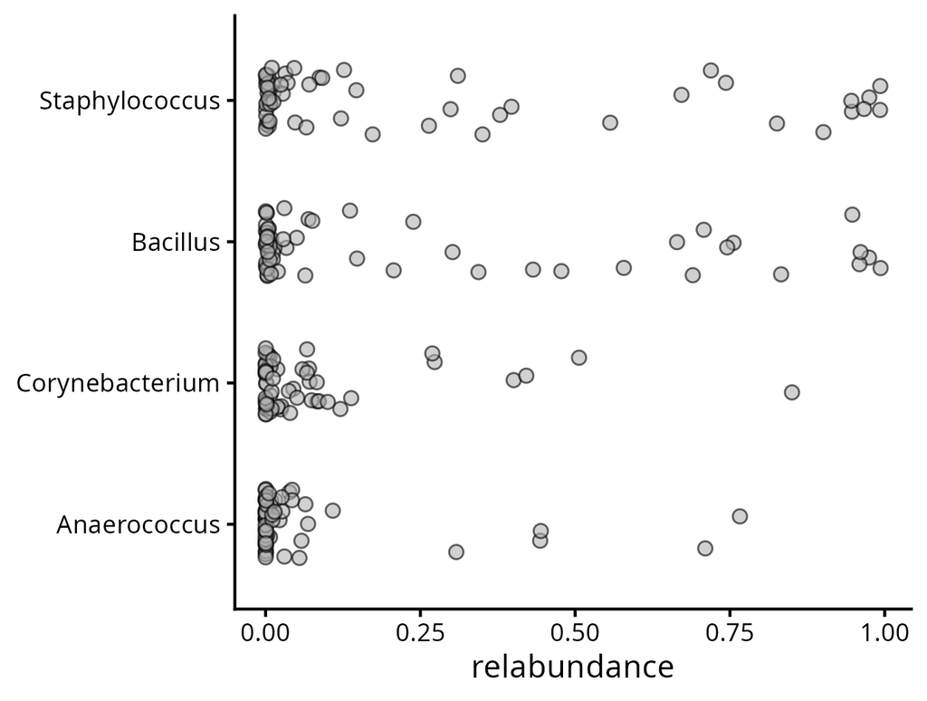

```r
core <- getPrevalent(
    tse_genus,
    assay.type = "relabundance",
    detection = 0.1 / 100,
    prevalence = 50 / 100)

plotAbundanceDensity(
    tse_genus[core, ],
    layout = "jitter",
    assay.type = "relabundance")
```

## Differential abundance

Which genera are associated with a group difference (e.g. sex)?

```r
library(DESeq2)

dds <- DESeqDataSet(tse_genus, design = ~ Gender)
dds <- DESeq(dds)
res <- results(dds)

top <- head(res[order(res$padj), ])
data.frame(log2FC = round(top$log2FoldChange, 2),
           padj = signif(top$padj, 2),
           row.names = rownames(top)) |>
    knitr::kable()
```

- DESeq2 (Love, Huber, and Anders 2014); for alternatives and benchmarks see the [OMA DAA chapter](https://microbiome.github.io/OMA/docs/devel/pages/differential_abundance.html)
- Compare several methods: results can differ substantially

## Differential abundance

|  | log2FC | padj |
| --- | --- | --- |
| Clostridium | 4.16 | 4.2e-06 |
| Pseudomonas | 5.06 | 4.2e-06 |
| Finegoldia | 5.93 | 2.1e-04 |
| Orientia | 4.23 | 6.1e-03 |
| Kocuria | -4.51 | 9.7e-03 |
| Amphritea | 5.42 | 1.4e-02 |

## Role of covariates

Key covariates (diet, medication, age, …) can change the interpretation.

- Stool consistency, medication and diet explain a considerable part of population-level gut microbiome variation (Falony et al. 2016)
- Include relevant covariates in **PERMANOVA** and **differential abundance** models
- Compare results with and without covariates

# Wrap-up

## Checklist for your report

Alpha

Indices, histogram, comparison

Beta

PCoA (BC vs CLR), PERMANOVA with covariates

Taxa

Prevalence, core microbiota, differential abundance

Report

Clear, compact, reproducible

## Resources

- [Orchestrating Microbiome Analysis (OMA)](https://microbiome.github.io/OMA/)
- mia and miaViz documentation
- [DESeq2 vignette](https://bioconductor.org/packages/devel/bioc/vignettes/DESeq2/inst/doc/DESeq2.html)

## References

Falony, Gwen, Marie Joossens, Sara Vieira-Silva, Jun Wang, Youssef Darzi, Karoline Faust, Alexander Kurilshikov, et al. 2016. “Population-Level Analysis of Gut Microbiome Variation.” *Science* 352 (6285): 560–64. https://doi.org/10.1126/science.aad3503.

Love, Michael I., Wolfgang Huber, and Simon Anders. 2014. “Moderated Estimation of Fold Change and Dispersion for RNA-seq Data with DESeq2.” *Genome Biology* 15 (12): 550. https://doi.org/10.1186/s13059-014-0550-8.

Salonen, A., J. Salojärvi, L. Lahti, and W. M. de Vos. 2012. “The Adult Intestinal Core Microbiota Is Determined by Analysis Depth and Health Status.” *Clinical Microbiology and Infection* 18 (s4): 16–20. https://doi.org/10.1111/j.1469-0691.2012.03855.x.

Wickham, Hadley, Mine Çetinkaya-Rundel, and Garrett Grolemund. 2023. *R for Data Science: Import, Tidy, Transform, Visualize, and Model Data*. 2nd ed. O’Reilly Media. https://r4ds.hadley.nz.